# Race & Oscars Winners

Mikayla Edwards

11/22/2020

## Hypothesis

I found 2 datasets with Oscars data. The first is called Oscars nominated movies 2000-2017 (https://www.kaggle.com/vipulgote4/oscars-nominated-movies-from-2000-to-2017) and the second is demographics (https://www.kaggle.com/fmejia21/demographics-of-academy-awards-oscars-winners). I hypothesize that due to the Oscars so White movement years prior, movies with higher proportions of people of color are less likely to win an award in any of the 5 categories below: - Best Picture won - Best Director won - Oscars Best Actor Won - Oscars Best Actress Won - People Choice won These categories were selected from the Oscars nominated movies dataset because they had both 'nomination' and 'winner' columns. They are also the most well-known categories. This allows me to optimize the amount of data I have for running my analysis. To look for films with people of color I used the race_simple column which respectively has people listed as White or POC, person of color. I also used Excel to add a column called POC_percent. This column was created by filtering the data by movie and then dividing the number of POC by the total amount of characters listed.

## Merging the Datasets

```r
library(readxl)
Oscar_nominated_Movies_2000_2017 <- read_excel("Desktop/Oscar nominated Movies 2000-2017.xlsx")
View(Oscar_nominated_Movies_2000_2017)

library(readxl)
demographics <- read_excel("Desktop/demographics.xlsx")
View(demographics)


library(dplyr)
Oscar_demographics <- inner_join(Oscar_nominated_Movies_2000_2017, demographics, by = c("movie" = "film"))
```

## Cleaning the data

The merged data had a lot of columns I wasn't interested in so I deleted the excess columns.

```r
Oscar_demographics <-Oscar_demographics[-c(1,3,4,5,6,7,8,9,10,11,12,13,14,15,16,17)]

Oscar_demographics <- Oscar_demographics[-c(3,5,7,9,11)]

Oscar_demographics <- Oscar_demographics[-c(8,9,10,11,12,13,14,15,16,17)]

Oscar_demographics <- Oscar_demographics[-c(8:18)]

Oscar_demographics <- Oscar_demographics[-c(8:25)]

Oscar_demographics <- Oscar_demographics[-c(8:15)]

Oscar_demographics <- Oscar_demographics[-c(8:11)]

Oscar_demographics <- Oscar_demographics[-c(9:40)]

Oscar_demographics <- Oscar_demographics[-c(9:19)]

Oscar_demographics <- Oscar_demographics[-c(9)]
Oscar_demographics <- Oscar_demographics[-c(6,7)]
View(Oscar_demographics)
```

## Binary

Next, I changed all the columns of interest from Yes or No / White or POC to their respective binary values. *For race_simple I made POC=1 and White=0

```r
Oscar_demographics$race_simple <- ifelse(Oscar_demographics$race_simple == "White", 0, 1)
Oscar_demographics$Oscar_Best_Picture_won <- ifelse(Oscar_demographics$Oscar_Best_Picture_won == "No", 0, 1)
Oscar_demographics$Oscar_Best_Actor_won <-ifelse(Oscar_demographics$Oscar_Best_Actor_won == "No", 0, 1)
Oscar_demographics$Oscar_Best_Actress_won <- ifelse(Oscar_demographics$Oscar_Best_Actress_won == "No", 0, 1)
Oscar_demographics$Oscar_Best_Director_won <- ifelse(Oscar_demographics$Oscar_Best_Director_won == "No", 0, 1)

View(Oscar_demographics)
```

## Correlation

Next, instead of running separate correlation analyses for each column with POC_percent and race_simple, I decided to run a correlation matrix to see them all at once.

```r
library(GGally)
```

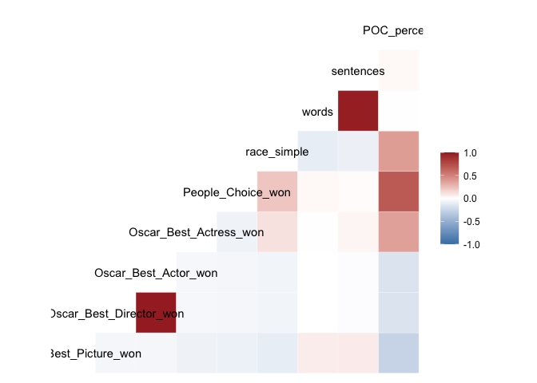

```r
ggcorr(Oscar_demographics, low = "steelblue", mid = "white", high = "brown")
```

It appears that the strongest correlations of POC_percent and race simple are both with the People_Choice_won category.

# Example

[interactive chart not shown]

An example of this correlation proving true can been seen in the graph above where The Martian had the highest POC_percent and won the People's Choice Award.

Updated 12/28/2022